# Project Description

Major League Baseball (MLB) uses a technology called Statcast to collect detailed data about the exact location and movements of baseballs and players during games. In this project, we will use Statcast data to compare the home run performance of two of the biggest stars who played for the New York Yankees: Aaron Judge and Giancarlo Stanton. The data for this project comes from Baseball Savant.

Aaron Judge is one of the largest players in MLB. He stands 6 feet 7 inches (2.01 meters) tall and weighs 282 pounds (128 kilograms). He also hit one of the hardest home runs ever recorded, and we know this because of the precise measurements from Statcast.

Statcast is a cutting-edge tracking system introduced in 2015 at all 30 major league ballparks. It uses high-resolution cameras and radar to measure the exact position and movement of baseballs and players. This data has changed how baseball teams analyze the game, creating a new focus on data-driven decisions. Teams compete by hiring analysts to gain advantages over their opponents.

In this project, we will clean, analyze, and visualize Statcast data to compare Aaron Judge and his teammate Giancarlo Stanton. Both players are known for hitting many home runs. In 2017, Stanton hit 59 home runs and Judge hit 52, leading the league by a large margin (the third-place player had 45 home runs).

Although Stanton and Judge share some similarities, they are also different in many ways. This project will explore how their home run hitting styles and performance compare.

## The Data

We will work with two CSV files: `judge.csv` and `stanton.csv`. These files contain Statcast data from 2015 to 2017. Each row in the files represents one pitch thrown to the batter.

## Custom Functions

We have created two custom functions to help visualize home run zones:

- `assign_x_coord`: This function assigns an x-coordinate based on Statcast’s strike zone numbering system.
- `assign_y_coord`: This function assigns a y-coordinate based on Statcast’s strike zone numbering system.

These functions will help us map pitches to specific locations in the strike zone, making it easier to compare how Judge and Stanton hit home runs.

```python
# Import the necessary packages
import pandas as pd
import matplotlib.pyplot as plt
import seaborn as sns

# Load Aaron Judge's Statcast data
judge = pd.read_csv('judge.csv')

# Load Giancarlo Stanton's Statcast data
stanton = pd.read_csv('stanton.csv')

# Display all columns (pandas will collapse some columns if we don't set this option)
pd.set_option('display.max_columns', None)

# Custom Functions
def assign_x_coord(row):
    """
    Assigns an x-coordinate to Statcast's strike zone numbers. Zones 11, 12, 13,
    and 14 are ignored for plotting simplicity.
    """
    # Left third of strike zone
    if row.zone in [1, 4, 7]:
        return 1
    # Middle third of strike zone
    if row.zone in [2, 5, 8]:
        return 2
    # Right third of strike zone
    if row.zone in [3, 6, 9]:
        return 3

def assign_y_coord(row):
    """
    Assigns a y-coordinate to Statcast's strike zone numbers. Zones 11, 12, 13,
    and 14 are ignored for plotting simplicity.
    """
    # Upper third of strike zone
    if row.zone in [1, 2, 3]:
        return 3
    # Middle third of strike zone
    if row.zone in [4, 5, 6]:
        return 2
    # Lower third of strike zone
    if row.zone in [7, 8, 9]:
        return 1

# Display the last five rows of the Aaron Judge file
judge.tail()
```

|  | pitch_type | game_date | release_speed | release_pos_x | release_pos_z | player_name | batter | pitcher | events | description | spin_dir | spin_rate_deprecated | break_angle_deprecated | break_length_deprecated | zone | des | game_type | stand | p_throws | home_team | away_team | type | hit_location | bb_type | balls | strikes | game_year | pfx_x | pfx_z | … |
| --- | --- | --- | --- | --- | --- | --- | --- | --- | --- | --- | --- | --- | --- | --- | --- | --- | --- | --- | --- | --- | --- | --- | --- | --- | --- | --- | --- | --- | --- | --- |
| 3431 | CH | 2016-08-13 | 85.6 | -1.9659 | 5.9113 | Aaron Judge | 592450 | 542882 | NaN | ball | NaN | NaN | NaN | NaN | 14.0 | NaN | R | R | R | NYY | TB | B | NaN | NaN | 0 | 0 | 2016 | -0.379108 | 0.370567 | … |
| 3432 | CH | 2016-08-13 | 87.6 | -1.9318 | 5.9349 | Aaron Judge | 592450 | 542882 | home_run | hit_into_play_score | NaN | NaN | NaN | NaN | 4.0 | Aaron Judge homers (1) on a fly ball to center... | R | R | R | NYY | TB | X | NaN | fly_ball | 1 | 2 | 2016 | -0.295608 | 0.320400 | … |
| 3433 | CH | 2016-08-13 | 87.2 | -2.0285 | 5.8656 | Aaron Judge | 592450 | 542882 | NaN | ball | NaN | NaN | NaN | NaN | 14.0 | NaN | R | R | R | NYY | TB | B | NaN | NaN | 0 | 2 | 2016 | -0.668575 | 0.198567 | … |
| 3434 | CU | 2016-08-13 | 79.7 | -1.7108 | 6.1926 | Aaron Judge | 592450 | 542882 | NaN | foul | NaN | NaN | NaN | NaN | 4.0 | NaN | R | R | R | NYY | TB | S | NaN | NaN | 0 | 1 | 2016 | 0.397442 | -0.614133 | … |
| 3435 | FF | 2016-08-13 | 93.2 | -1.8476 | 6.0063 | Aaron Judge | 592450 | 542882 | NaN | called_strike | NaN | NaN | NaN | NaN | 8.0 | NaN | R | R | R | NYY | TB | S | NaN | NaN | 0 | 0 | 2016 | -0.823050 | 1.623300 | … |

### How many of each event did Judge and Stanton have in 2017?

```python
# All of Aaron Judge's batted ball events in 2017
judge_events_2017 = judge.loc[judge['game_year'] == 2017].events.value_counts()
print("Aaron Judge batted ball event totals, 2017:")
print(judge_events_2017)

# All of Giancarlo Stanton's batted ball events in 2017
stanton_events_2017 = stanton.loc[stanton['game_year'] == 2017].events.value_counts()
print("\nGiancarlo Stanton batted ball event totals, 2017:")
print(stanton_events_2017)
```

```
Aaron Judge batted ball event totals, 2017:
events
strikeout                    207
field_out                    146
walk                         116
single                        75
home_run                      52
double                        24
grounded_into_double_play     15
force_out                     11
intent_walk                   11
hit_by_pitch                   5
sac_fly                        4
fielders_choice_out            4
field_error                    4
triple                         3
strikeout_double_play          1
Name: count, dtype: int64

Giancarlo Stanton batted ball event totals, 2017:
events
field_out                    239
strikeout                    161
single                        77
walk                          72
home_run                      59
double                        32
intent_walk                   13
grounded_into_double_play     13
force_out                      7
hit_by_pitch                   7
field_error                    5
sac_fly                        3
fielders_choice_out            2
strikeout_double_play          2
pickoff_1b                     1
Name: count, dtype: int64
```

### Which player hits home runs slightly lower and slightly harder?

```python
import warnings
warnings.filterwarnings("ignore", category=FutureWarning)
```

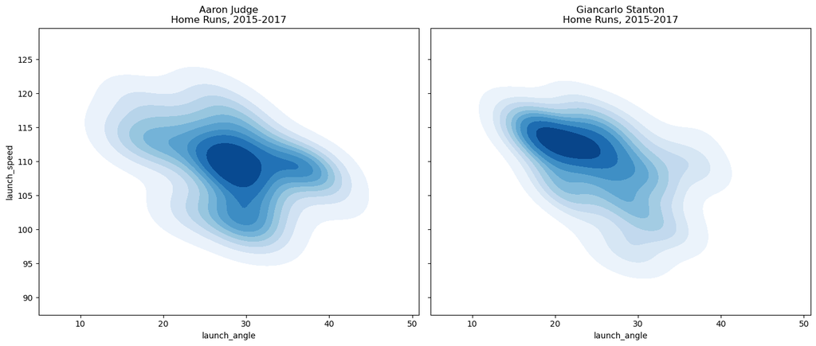

```python
# Filter to include home runs only
judge_hr = judge.loc[judge['events'] == 'home_run']
stanton_hr = stanton.loc[stanton['events'] == 'home_run']

# Create a figure with two KDE plots
fig1, ax1 = plt.subplots(ncols=2, sharex=True, sharey=True, figsize=(14, 6))

sns.kdeplot(
    x=judge_hr.launch_angle,
    y=judge_hr.launch_speed,
    cmap="Blues",
    fill=True,
    thresh=0.05,
    ax=ax1[0]
).set_title('Aaron Judge\nHome Runs, 2015-2017')

sns.kdeplot(
    x=stanton_hr.launch_angle,
    y=stanton_hr.launch_speed,
    cmap="Blues",
    fill=True,
    thresh=0.05,
    ax=ax1[1]
).set_title('Giancarlo Stanton\nHome Runs, 2015-2017')

plt.tight_layout()
plt.show()
```

```python
player_hr = "Stanton"
```

### Compare both players' pitch velocity, or `release_speed`. Which player has the highest median?

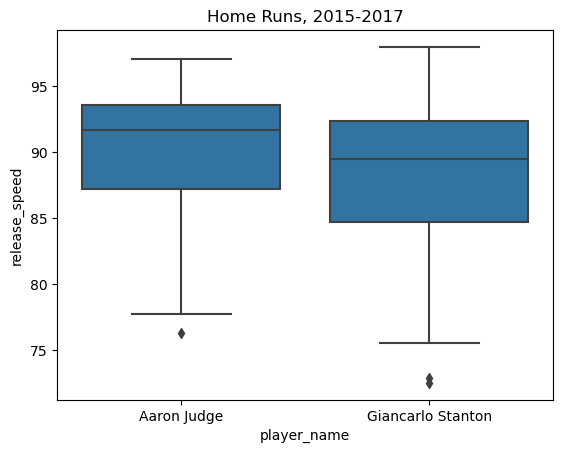

```python
# Combine the Judge and Stanton home run DataFrames
judge_stanton_hr = pd.concat([judge_hr, stanton_hr])

# Create a boxplot
sns.boxplot(x='player_name', y='release_speed', color='tab:blue', data=judge_stanton_hr).set_title('Home Runs, 2015-2017')
```

```python
player_fast = "Judge"
```

### Create a 2D histogram for each player that visualizes the home run strike zones, ignoring zones 11, 12, 13, and 14 for simplicity.

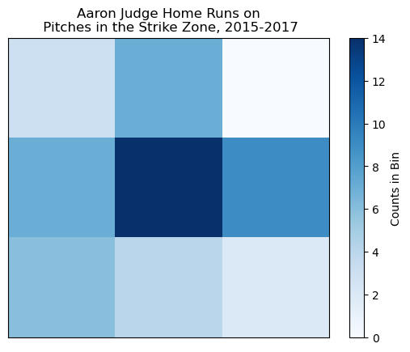

```python
# Zones 11, 12, 13, and 14 are to be ignored for plotting simplicity
judge_strike_hr = judge_hr.copy().loc[judge_hr.zone <= 9]

# Assign Cartesian coordinates to pitches in the strike zone for Judge home runs
judge_strike_hr['zone_x'] = judge_strike_hr.apply(assign_x_coord, axis=1)
judge_strike_hr['zone_y'] = judge_strike_hr.apply(assign_y_coord, axis=1)

# Plot Judge's home run zone as a 2D histogram with a colorbar and save the figure to a variable
plt.hist2d(judge_strike_hr.zone_x, judge_strike_hr.zone_y, bins = 3, cmap='Blues')
plt.title('Aaron Judge Home Runs on\n Pitches in the Strike Zone, 2015-2017')
plt.gca().get_xaxis().set_visible(False)
plt.gca().get_yaxis().set_visible(False)
cb = plt.colorbar()
cb.set_label('Counts in Bin')
```

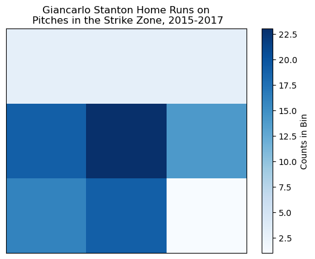

```python
# Zones 11, 12, 13, and 14 are to be ignored for plotting simplicity
stanton_strike_hr = stanton_hr.copy().loc[stanton_hr.zone <= 9]

# Assign Cartesian coordinates to pitches in the strike zone for Stanton home runs
stanton_strike_hr['zone_x'] = stanton_strike_hr.apply(assign_x_coord, axis=1)
stanton_strike_hr['zone_y'] = stanton_strike_hr.apply(assign_y_coord, axis=1)

# Plot Stanton's home run zone as a 2D histogram with a colorbar
plt.hist2d(stanton_strike_hr.zone_x, stanton_strike_hr.zone_y, bins = 3, cmap='Blues')
plt.title('Giancarlo Stanton Home Runs on\n Pitches in the Strike Zone, 2015-2017')
plt.gca().get_xaxis().set_visible(False)
plt.gca().get_yaxis().set_visible(False)
cb = plt.colorbar()
cb.set_label('Counts in Bin')
```